# *RMeDPower2*: helping design and analyses of data from repeated measures experiments

Min-Gyoung Shin and Reuben Thomas

Gladstone Institutes

mingyoung.shin@gladstone.ucsf.edu  
reuben.thomas@gladstone.ucsf.edu

14 August 2025

#### Abstract

Biomedical research very often involves data generated from repeated measures experiments. RMeDPower2 is an R package that provides complete functionality to analyse data coming from repeated measures experiments, i.e., where one has repeated measures from the same biological/independent units or samples. RMeDPower2 helps test the modeling assumptions one makes, identify outlier observations, outlier units at different levels of the design, estimates statistical power or perform sample size calculations, estimate parameters of interest and also to visualize the association being tested. The functionality is limited to testing associations of one predictor (continuous or categorical, e.g., disease status or brain pathology) along with one another covariate (e.g., gender status) in the context of hierarchical or crossed experimental designs. This vignette illustrates the use of this package in multiple contexts relevant to biomedical research.

RMeDPower2 defines the experimental design for the data, probability model of the data generating distribution and necessary parameters required for sample size calculation using convenient S4 class objects. It uses these objects in one framework that brings together the functionality implemented in multiple R packages - lme4 (implementation of linear mixed effects models), influence.ME (identification of outlier units), EnvStats (identification of outlier observations), DHARMa (testing of modeling assumptions for non-normal distributions), simr (sample-size calculations) and tidyverse (data manipulation and visualization).

#### Package

RMeDPower2 0.1.0

# 1 Getting started

## 1.1 Installing `RMeDPower2`

`RMeDPower2` can be installed using the following commands

```r
install.packages("devtools")
library(devtools)
install_github('gladstone-institutes/RMeDPower2', build_vignettes=TRUE)
##load the library
library(RMeDPower2)
```

## 1.2 Quick tutorial

The workflow can be accomplished in 5 main steps.

### 1.2.1 Input data

Read-in the input data as a data frame

```r
library(RMeDPower2)
template_dir <- "~/Dropbox (Gladstone)/calcPower f1000_manuscript/Final_paper_materials/Revisions/input_templates/cell_assay_data/"

data <- read.csv(paste0(template_dir, "cell_size_data.csv"), header = T)
```

### 1.2.2 Specify design, model and power parameters

1. Use a text editor to modify the template jsonfile capturing the design file and read in this file.

```r
design <- readDesign(paste0(template_dir,"design_cell_assay.json"))
```

2. Use a text editor to modify the template jsonfile capturing the error probability model file and read in this file.

```r
model <- readProbabilityModel(paste0(template_dir,"prob_model.json"))
```

3. Use a text editor to modify the template jsonfile capturing the power parameters file and read in this file.

```r
power_param <- readPowerParams(paste0(template_dir,"power_param.json"))
```

### 1.2.3 Diagnose data and model

1. Diagnose the data and model, test model assumptions, identify outlier observations, outlier biological/independent units

```r
diagnose_res <- diagnoseDataModel(data, design, model)
```

2. Modify design objects (e.g., remove outliers), model objects (e.g., change probability distribution assumption) if needed based on output of step 1 above.

```r
diagnose_res_update <- diagnoseDataModel(data_update, design_update, model_update)
```

3. Repeat steps 1 and 2 until the models assumptions are met

### 1.2.4 Statistical power estimation

Run sample-size calculations

```r
power_res <- calculatePower(data, design, model, power_param)
```

### 1.2.5 Estimate parameters of interest

Estimate and visualize parameters of interest.

```r
estimate_res <- getEstimatesOfInterest(data, design, model)
```

## 1.3 Input data

Users will have to ensure that the input data is a table with rows representing the individual observations or responses and columns representing not only the corresponding predictor/independent variables but also other variables that capture the hierarchical or crossed design of how the data was generated. It is important that the columns have names or headers - these column names will be used to define the relevant S4 class objects.

For example, below illustrates the input data from a cellular assay where each of the 2,588 observations represents a measurement of size (`cell_size2`) of a single cell, from a given cell line (`line`) that is either from a control or disease condition (`classification`) and is measured in a given experimental batch (`experiment`).

```
## 'data.frame':    2588 obs. of  4 variables:
##  $ experiment    : Factor w/ 3 levels "experiment1",..: 1 1 1 1 1 1 1 1 1 3 ...
##  $ line          : Factor w/ 10 levels "cellline1","cellline10",..: 1 1 1 1 1 1 1 1 1 1 ...
##  $ classification: Factor w/ 2 levels "0","1": 1 1 1 1 1 1 1 1 1 1 ...
##  $ cell_size2    : num  354 456 351 387 404 ...
```

## 1.4 Three key classes of `RMeDPower2`

### 1.4.1 `RMeDesign` S4 class

The underlying design for the data will be stored in an object of this class. The slots of this class are:

1. `response_column`: character that is the column name in the input data table that captures the responses or individual observations. This has to be set by the user.
2. `covariate`: character that is the column name in the input data table that captures the covariate information. This will be used as a fixed effect in the mixed effects model of the data. This slot is set to `NULL` if there are no covariates.
3. `condition_column`: character that is the column name in the input data table that captures the predictor/independent variable information. This will be used as a fixed effect in the mixed effects model of the data.This has to be set by the user.
4. `experimental_columns`: character vector that represents the column names in the input data table that captures the experimental variables of the design. These will be used as random effects in the mixed effects model of the data. The order of the names in this character vector is important. The first element captures the top hierarchical level of the design, the second element the next level of the hierarchy and so on. The hierarchy is explicitly modeled in the specification of the mixed effects models. The hierarchy will not be modeled for variables specified in the `crossed_columns` slot (see below). This has to be set by the user.
5. `condition_is_categorical`: logical value equal to TRUE if the variable in the `condition_column` is to be considered as a categorical variable and is equal to FALSE otherwise. Defaults to TRUE.
6. `crossed_columns`: character vector that represents the column names in the input data table that are a subset of the values in `experimental_columns` representing crossed factors. Defaults to `NULL`.
7. `total_column`: character that is the column name in the input table that will be used to offset values in the mixed effects models. Useful for modeling count data. Defaults to `NULL`.
8. `outlier_alpha`: numeric value that is the p-value threshold used to identify outlier observations. Defaults to 0.05.
9. `na_action`: character equal to *complete* or *unique*. To be used in the context where the input data has multiple responses that will each be sequentially modeled. *complete* refers to the situation where outlier observations identified for one response will also be identified as outliers for all the other responses while *unique* refers to the situation where the outlier observations identified for one response will only be used for the model of that particular response. Defaults to *complete*.

We can create an object of class `RMeDesign` using the function.

```r
design <- new("RMeDesign")
print(design)
```

```
## An object of class "RMeDesign"
## Slot "response_column":
## [1] "response_column"
##
## Slot "covariate":
## NULL
##
## Slot "condition_column":
## [1] "condition_column"
##
## Slot "condition_is_categorical":
## [1] TRUE
##
## Slot "experimental_columns":
## [1] "experimental_column"
##
## Slot "crossed_columns":
## NULL
##
## Slot "total_column":
## NULL
##
## Slot "outlier_alpha":
## [1] 0.05
##
## Slot "na_action":
## [1] "complete"
##
## Slot "include_interaction":
## [1] FALSE
##
## Slot "random_slope_variable":
## NULL
```

In practice, for a given data set the design can be input from a jsonfile. The user can use a text editor to modify the `design_template.json` file available with the package to input the relevant information based on the column names of the input data. For example, the design for the cell size data referred to above can be read using the function `readDesign`,

```r
template_dir <- "~/Dropbox (Gladstone)/calcPower f1000_manuscript/Final_paper_materials/Revisions/input_templates/cell_assay_data/"

design <- readDesign(paste0(template_dir,"design_cell_assay.json"))
print(design)
```

```
## An object of class "RMeDesign"
## Slot "response_column":
## [1] "cell_size2"
##
## Slot "covariate":
## NULL
##
## Slot "condition_column":
## [1] "classification"
##
## Slot "condition_is_categorical":
## [1] TRUE
##
## Slot "experimental_columns":
## [1] "experiment" "line"
##
## Slot "crossed_columns":
## [1] "line"
##
## Slot "total_column":
## NULL
##
## Slot "outlier_alpha":
## [1] 0.05
##
## Slot "na_action":
## [1] "complete"
##
## Slot "include_interaction":
## [1] FALSE
##
## Slot "random_slope_variable":
## NULL
```

### 1.4.2 `ProbabilityModel` S4 class

The error probability distribution is specified by two slots in objects of the `ProbabilityModel` class.

1. `error_is_non_normal`: logical value that is TRUE if the underlying probability distribution is not assumed to be Normal and is FALSE otherwise.
2. `family_p`: character value that specifies the probability distribution. Accepted values are *poisson*(`=poisson(link="log")`), *binomial*(`=binomial(link="logit")`), *bionomial_log*(`=binomial(link="log")`), *Gamma_log*(`=Gamma(link="log")`), *Gamma*(`=Gamma(link="inverse")`), *negative_binomial*. Defaults to `NULL`.

```r
model <- readProbabilityModel(paste0(template_dir,"prob_model.json"))
print(model)
```

```
## An object of class "ProbabilityModel"
## Slot "error_is_non_normal":
## [1] FALSE
##
## Slot "family_p":
## NULL
```

### 1.4.3 `PowerParams` S4 class

The parameters necessary for sample-size estimation are stored in the following slots of the `PowerParams` class.

1. `target_columns`: character vector with column names of experimental variables for which the sample-size estimation is to be performed
2. `power_curve`: numeric 1 or 0. 1: Power simulation over a range of sample sizes or levels. 0: Power calculation over a single sample size or a level. Defaults to 1.
3. `nsimn`: The number of simulations to estimate power. Defaults to 10.
4. `levels`: numeric 1 or 0. 1: Amplify the number of corresponding target parameter. 0: Amplify the number of samples from the corresponding target parameter, ex) If target_columns = c(“experiment”,“cell_line”) and if you want to expand the number of experiment and sample more cells from each cell line, set levels = c(1,0).
5. `max_size`: Maximum levels or sample sizes to test. Default if set to `NULL` equals the current level or the current sample size x 5. ex) If max_levels = c(10,5), it will test upto 10 experiments and 5 cell lines.
6. `alpha`: Type I error for sample-size estimation. Defaults to 0.05.
7. `breaks`: Levels /sample sizes of the variable to be specified along the power curve. Default if set to `NULL` equals max(1, round( the number of current levels / 5 ))
8. `effect_size`: If you know the effect size of your condition variable, the effect size can be provided as a parameter. Default set to `NULL`, that is, if the effect size is not provided, it will be estimated from your data,
9. `icc`: Intra-class coefficients for each of the experimental variables. Used only in the situation when `error_is_non_normal=FALSE` and when the data does not allow variance component estimation

```r
power_param <- readPowerParams(paste0(template_dir,"power_param.json"))
print(power_param)
```

```
## An object of class "PowerParams"
## Slot "target_columns":
## [1] "experiment"
##
## Slot "power_curve":
## [1] 1
##
## Slot "nsimn":
## [1] 10
##
## Slot "levels":
## [1] 1
##
## Slot "max_size":
## [1] 1
##
## Slot "alpha":
## [1] 0.05
##
## Slot "breaks":
## NULL
##
## Slot "effect_size":
## NULL
##
## Slot "icc":
## NULL
```

## 1.5 Three key functions of `RMeDPower2`

### 1.5.1 `diagnoseDataModel(data, design, model)` function

Tests the model assumptions using quantile-quantile, residuals vs fitted and residuals versus predicted plots, transforms responses if feasible and identifies outlier observations and also outlier experimental units

### 1.5.2 `calculatePower(data, design, model, power_param)` function

Performs sample-size calculations for given experimental design/target variable

### 1.5.3 `getEstimatesOfInterest(data, design, model)` function

Estimates parameter of interest and also plots the resulting association with predictor of interest using residuals from the model that removes the effects of the modeled experimental variables

# 2 Application examples

## 2.1 Plate assays

iPSC lines from control and patient derived iPSCs from sALS patients were obtained through the Answer ALS (AALS) consortium36 . AALS is the largest repository of ALS patient samples, and contains publicly available patient-specific iPSCs and multi-OMIC data from motor neurons derived from those iPSCs—including RNA Seq, proteomics and whole genome sequence data— all of which is matched with longitudinal clinical data (https://dataportal.answerals.org/home)36.

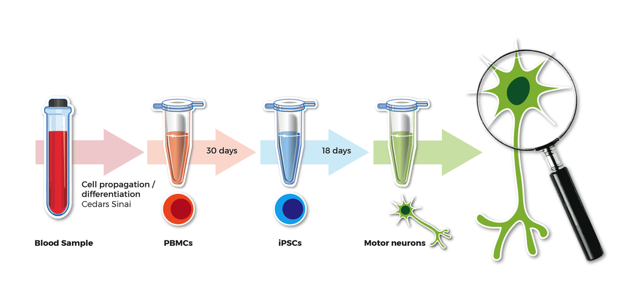

Figure 1: iPSC-derived ALS cell lines

We used 6 control lines and 4 sALS lines. We differentiated each line into motor neurons, transduced with a morphology marker and imaged on day ~25 using RM37-45 as previously described36. Images were processed and the soma size of neurons were captured using contour ellipse46 function adapted for use in python (https://www.python.org/).

```r
template_dir <- "~/Dropbox (Gladstone)/calcPower f1000_manuscript/Final_paper_materials/Revisions/input_templates/cell_assay_data/"

data <- read.csv(paste0(template_dir, "cell_size_data.csv"), header = T)
design <- readDesign(paste0(template_dir,"design_cell_assay.json"))
model <- readProbabilityModel(paste0(template_dir,"prob_model.json"))
power_param <- readPowerParams(paste0(template_dir,"power_param.json"))
```

Diagnose the data and the model

```r
diagnose_res <- diagnoseDataModel(data, design, model)
```

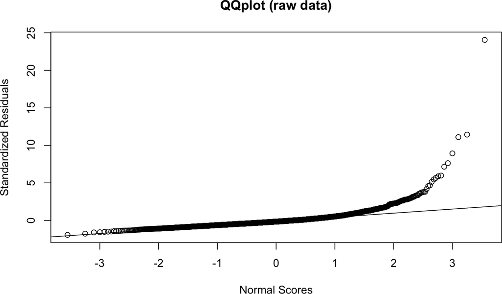

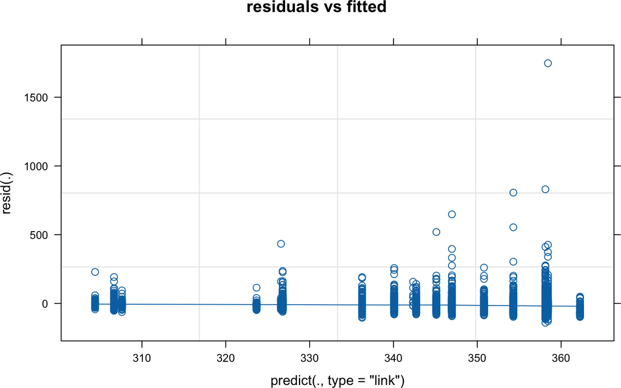

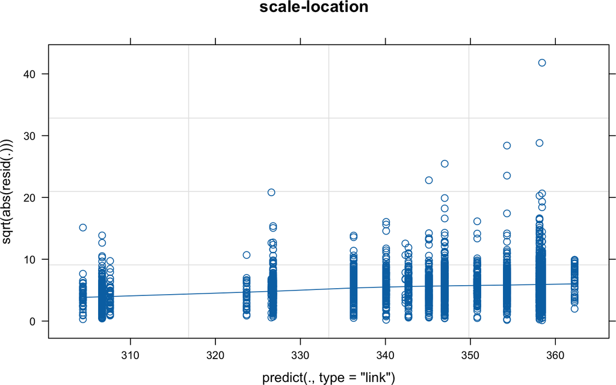

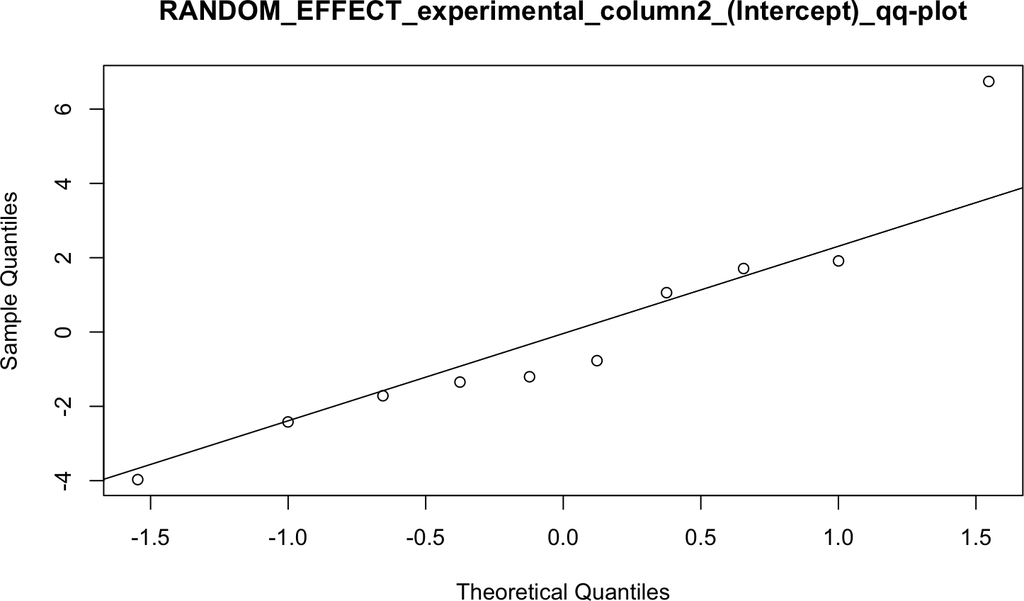

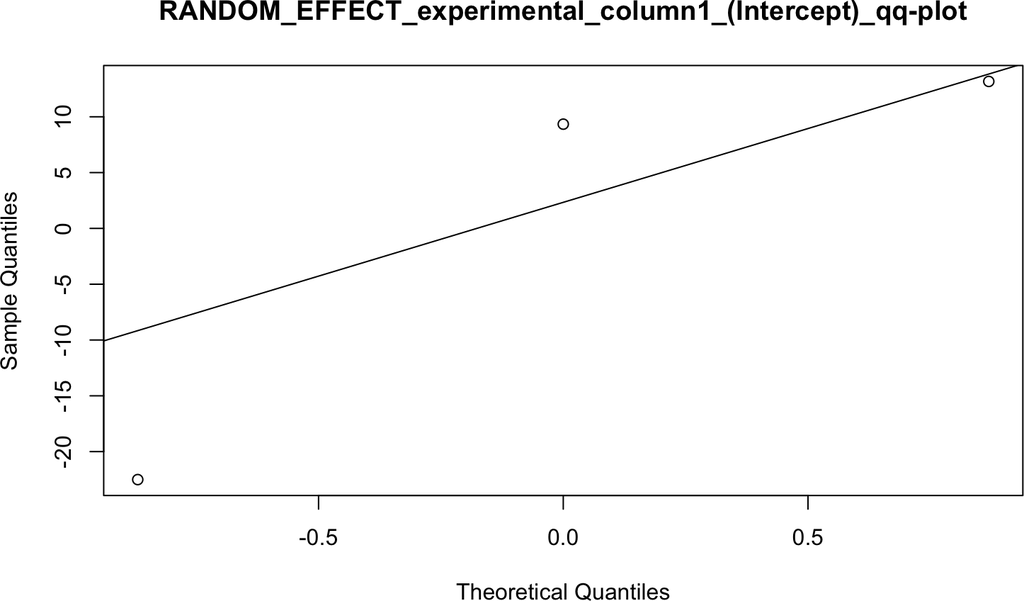

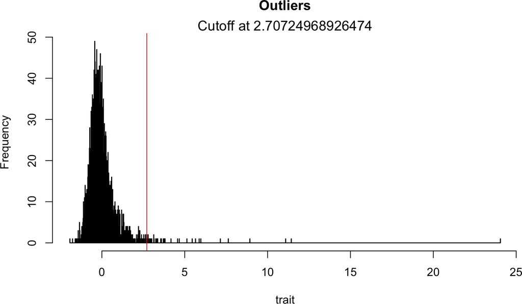

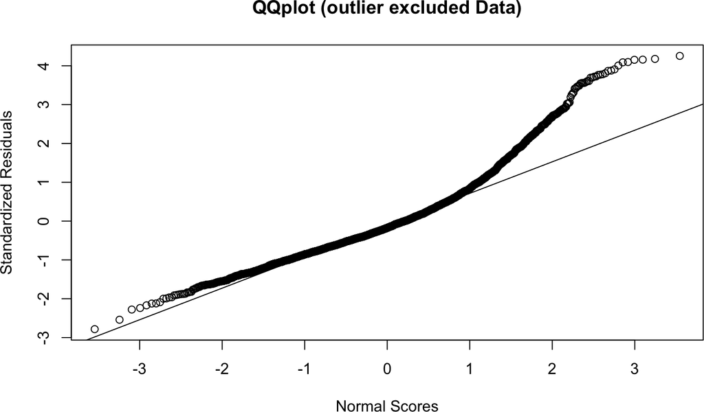

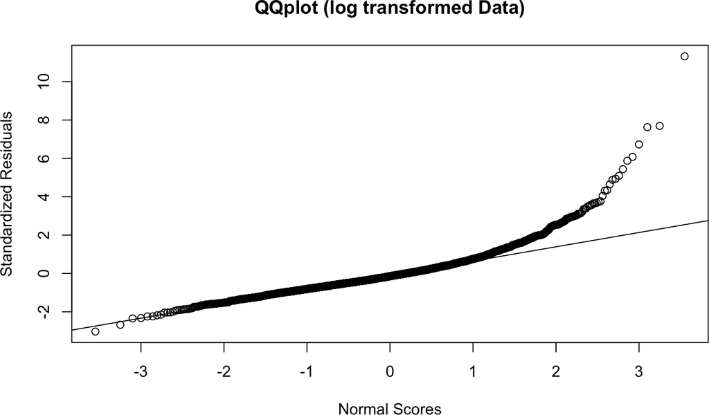

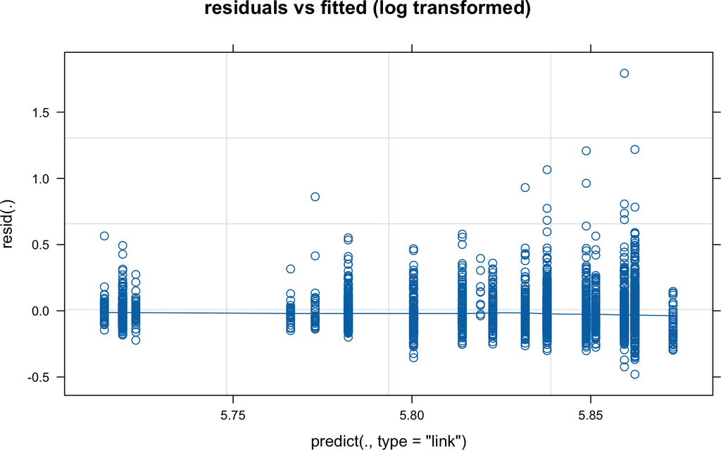

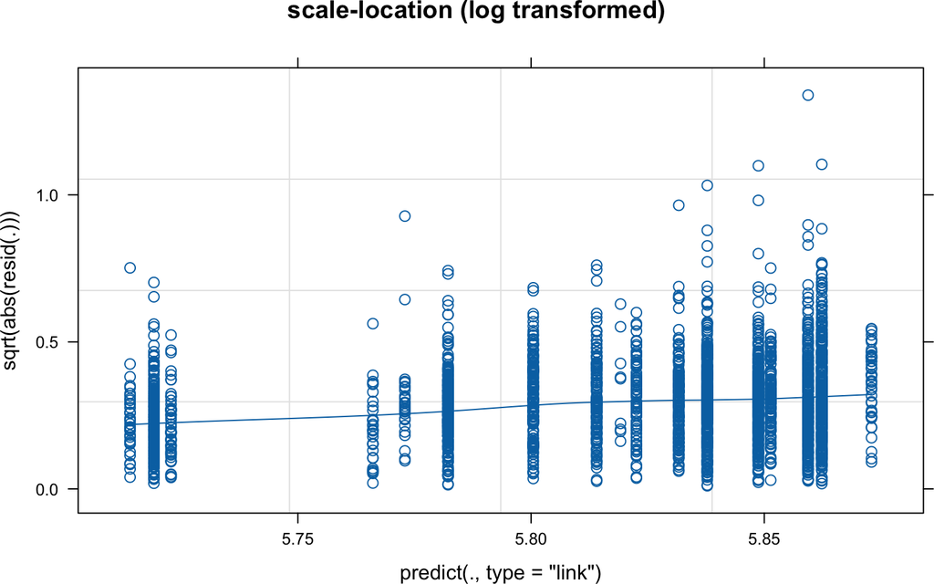

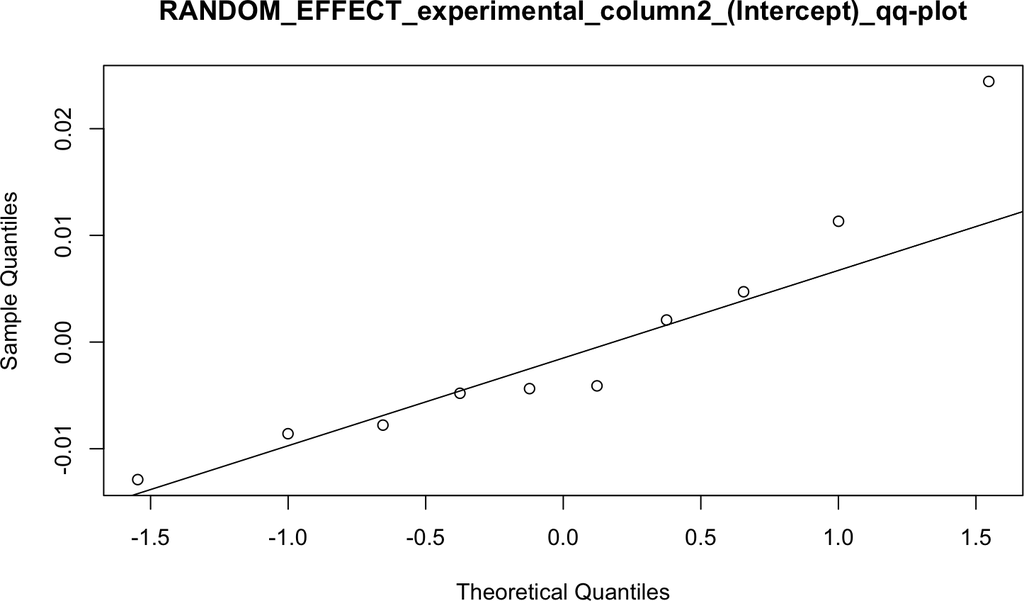

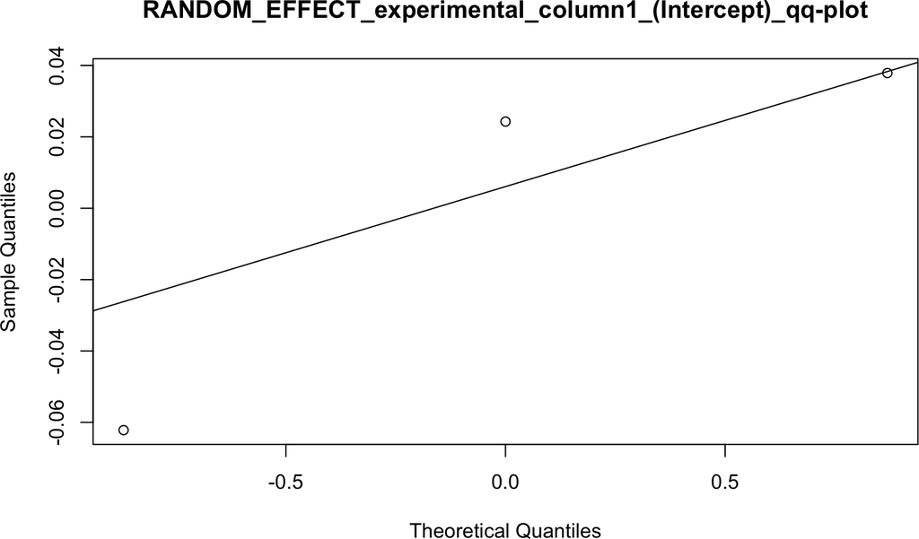

[2 more figures not shown]

Check for outlier experimental batches

```r
##see which experimental columns correspond to which variable
print(design@experimental_columns)
```

```
## [1] "experiment" "line"
```

```r
print(diagnose_res$cooks_distance_experimental_column1)
```

```
##                  [,1]
## experiment1 0.1296877
## experiment2 0.1336167
## experiment3 8.2524792
```

It looks like `experiment3` batch seems like an outlier. Now, check for outlier cell lines

```r
print(diagnose_res$cooks_distance_experimental_column2)
```

```
##                   [,1]
## cellline1  0.068029049
## cellline10 0.013060497
## cellline2  0.002640865
## cellline3  0.310579118
## cellline4  0.048632666
## cellline5  0.005197939
## cellline6  0.002647991
## cellline7  0.009832710
## cellline8  0.005479500
## cellline9  0.890608611
```

The qq plots of the residuals resulting from log transformation of the cell-size responses and the removal of outliers seems to deviate least from normality (though they still do seem non-normal). In any case, we will use these data for parameter estimation.

```r
design_update <- design
data_update <- diagnose_res$Data_updated
print(colnames(data_update))
```

```
##  [1] "cell_size2_logTransformed_noOutlier" "cell_size2_logTransformed"
##  [3] "cell_size2_noOutlier"                "experiment"
##  [5] "line"                                "classification"
##  [7] "cell_size1"                          "cell_size2"
##  [9] "cell_size3"                          "cell_size4"
## [11] "cell_size5"                          "cell_size6"
```

```r
design_update@response_column <-  "cell_size2_logTransformed_noOutlier"
estimate_res <- getEstimatesOfInterest(data_update, design_update, model)
```

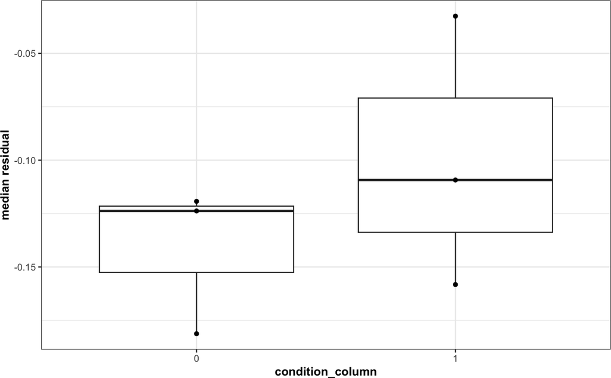

```r
##print model summary output
print(estimate_res[[1]])
```

```
## Linear mixed model fit by REML. t-tests use Satterthwaite's method [
## lmerModLmerTest]
## Formula: response_column ~ condition_column + (1 | experimental_column1) +
##     (1 | experimental_column2)
##    Data: fixed_global_variable_data
##
## REML criterion at convergence: -3072
##
## Scaled residuals:
##     Min      1Q  Median      3Q     Max
## -3.5014 -0.6566 -0.1274  0.5318  3.7581
##
## Random effects:
##  Groups               Name        Variance  Std.Dev.
##  experimental_column2 (Intercept) 0.0002444 0.01563
##  experimental_column1 (Intercept) 0.0028717 0.05359
##  Residual                         0.0173003 0.13153
## Number of obs: 2549, groups:  experimental_column2, 10; experimental_column1, 3
##
## Fixed effects:
##                   Estimate Std. Error      df t value Pr(>|t|)
## (Intercept)        5.78400    0.03189 2.14285 181.376 1.59e-05 ***
## condition_column1  0.03682    0.01220 8.08924   3.018   0.0164 *
## ---
## Signif. codes:  0 '***' 0.001 '**' 0.01 '*' 0.05 '.' 0.1 ' ' 1
##
## Correlation of Fixed Effects:
##             (Intr)
## cndtn_clmn1 -0.155
```

We can also perform calculate the number of experimental batches needed to estimate the observed differences in soma size.

```r
power_res <- calculatePower(data_update, design_update, model, power_param)
```

[output not shown]

## 2.2 single-cell RNA-seq assays

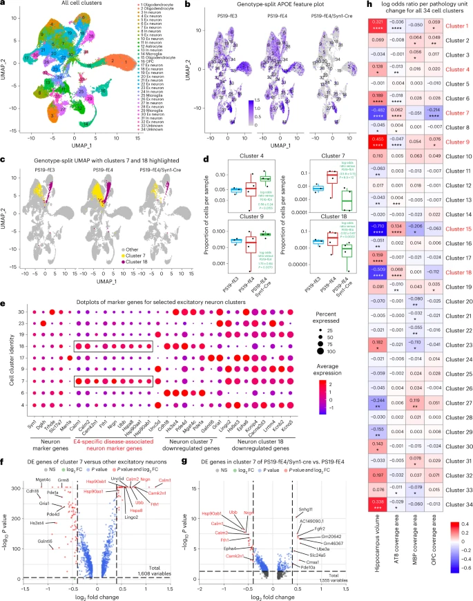

Figure 2: single nuclei RNA sequencing

### 2.2.1 Cell-type/cluster associations

We can first ask the question whether or not the proportion of nuclei derived from the APOE4-KI mice are different in cluster 7 compared to those derived from the APOE4-KI-Syn1-Cre mice. More exactly, we want to test whether or not there is a difference in the log odds of cluster membership in cluster 7 among the APOE4-KI mice versus the APOE4-KI-Syn1-Cre. The data consists of the number of nuclei per animal present in the cluster and also the total number of nuclei that were isolated from this animal.

#### 2.2.1.1 Associations with genotype

```r
template_dir <- "~/Dropbox (Gladstone)/calcPower f1000_manuscript/Final_paper_materials/Revisions/input_templates/single_cell_data/celltype_proportions_with_genotype/"
data <- read.csv(paste0(template_dir, "apoe_associated_cell_proportions.csv"), header = T)
head(data)
```

```
##   sample_id      animal_model total_numbers_of_cells_per_sample cluster_id
## 1       S10          PS19-fE4                              6552          7
## 2       S11          PS19-fE4                              6214          7
## 3       S12 PS19-fE4 Syn1-Cre                              7873          7
## 4       S13 PS19-fE4 Syn1-Cre                              6577          7
## 5        S4          PS19-fE4                             16223          7
## 6        S5          PS19-fE4                             12357          7
##   number_of_cells_per_sample_in_cluster          Genotype Mouse_. Sex PS19 Cre
## 1                                   263          PS19-fE4     154   F    +   -
## 2                                     8          PS19-fE4     413   M    +   -
## 3                                    58 PS19-fE4_Syn1-Cre     305   M    + +_-
## 4                                     1 PS19-fE4_Syn1-Cre     504   F    + +_-
## 5                                  2139          PS19-fE4     129   F    +   -
## 6                                  1811          PS19-fE4     156   M    +   -
##   ApoE      DOB Age_Perfused Date_Perfused Date_of_Nuc_Isolation
```

[output cut: 27 more lines]

```r
##load the design
design <- readDesign(paste0(template_dir,"design_celltype1.json"))
print(design)
```

```
## An object of class "RMeDesign"
## Slot "response_column":
## [1] "number_of_cells_per_sample_in_cluster"
##
## Slot "covariate":
## [1] "Sex"
##
## Slot "condition_column":
## [1] "Genotype"
##
## Slot "condition_is_categorical":
## [1] TRUE
##
## Slot "experimental_columns":
## [1] "sample_id"
##
## Slot "crossed_columns":
## NULL
##
## Slot "total_column":
## [1] "total_numbers_of_cells_per_sample"
##
## Slot "outlier_alpha":
## [1] 0.05
##
## Slot "na_action":
## [1] "complete"
##
## Slot "include_interaction":
## [1] FALSE
##
## Slot "random_slope_variable":
## NULL
```

```r
##load the probability model
model <- readProbabilityModel(paste0(template_dir,"prob_model.json"))
print(model)
```

```
## An object of class "ProbabilityModel"
## Slot "error_is_non_normal":
## [1] TRUE
##
## Slot "family_p":
## [1] "binomial"
```

```r
##load the relevant power parameters
power_param <- readPowerParams(paste0(template_dir,"power_param.json"))
print(power_param)
```

```
## An object of class "PowerParams"
## Slot "target_columns":
## [1] "sample_id"
##
## Slot "power_curve":
## [1] 1
##
## Slot "nsimn":
## [1] 10
##
## Slot "levels":
## [1] 1
##
## Slot "max_size":
## [1] 1
##
## Slot "alpha":
## [1] 0.05
##
## Slot "breaks":
## NULL
##
## Slot "effect_size":
## NULL
##
## Slot "icc":
## NULL
```

Now, we will diagnose the data and the model.

```r
diagnose_res <- diagnoseDataModel(data, design, model)
```

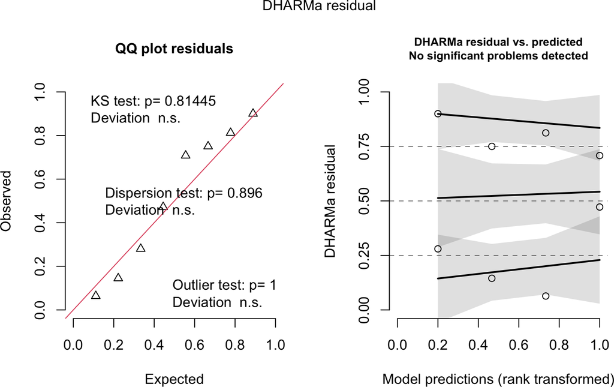

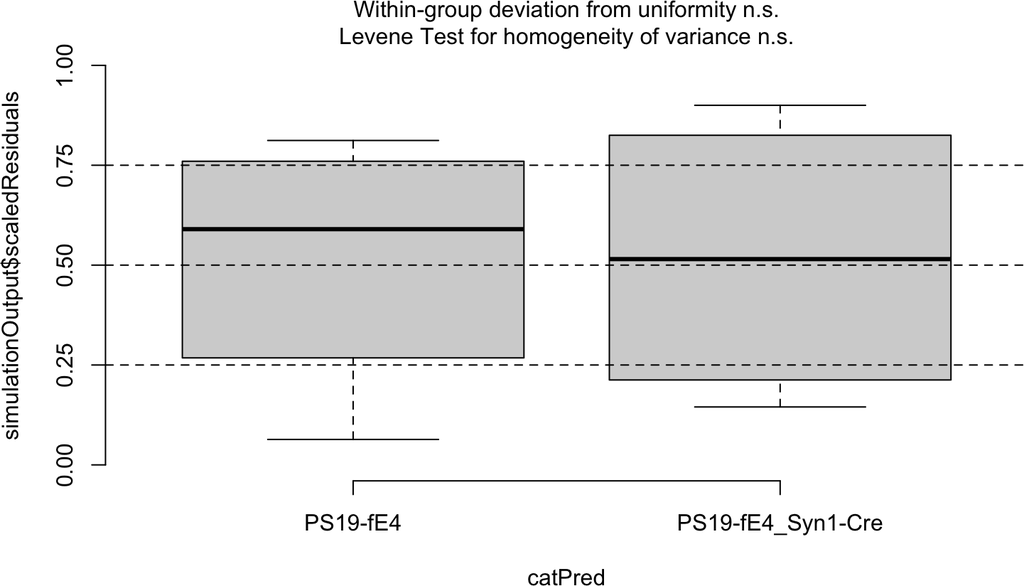

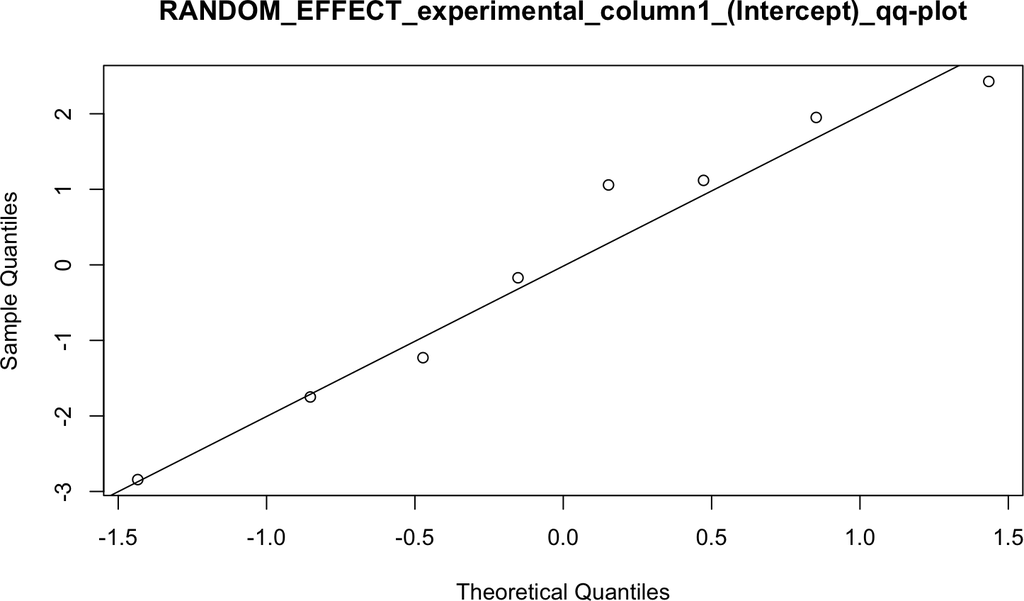

```
## [1] "No outlier detected from the raw Data"
```

We can now estimate the log odds ratio of interest.

```r
estimate_res <- getEstimatesOfInterest(data, design, model)
```

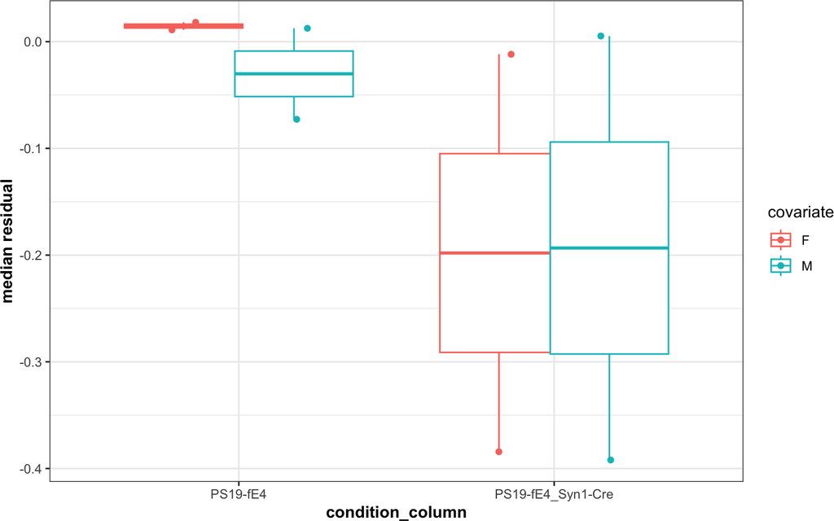

```r
print(estimate_res[[1]])
```

```
## Generalized linear mixed model fit by maximum likelihood (Laplace
##   Approximation) [glmerMod]
##  Family: binomial  ( logit )
## Formula:
## cbind(response_column, (total_column - response_column)) ~ condition_column +
##     covariate + (1 | experimental_column1)
##    Data: fixed_global_variable_data
##
##       AIC       BIC    logLik -2*log(L)  df.resid
##     100.9     101.2     -46.4      92.9         4
##
## Scaled residuals:
##      Min       1Q   Median       3Q      Max
## -0.41163 -0.28356  0.00219  0.02755  0.09292
##
## Random effects:
##  Groups               Name        Variance Std.Dev.
##  experimental_column1 (Intercept) 3.464    1.861
## Number of obs: 8, groups:  experimental_column1, 8
##
## Fixed effects:
##                                   Estimate Std. Error z value Pr(>|z|)
## (Intercept)                        -3.0030     1.1493  -2.613  0.00898 **
## condition_columnPS19-fE4_Syn1-Cre  -3.6302     1.3514  -2.686  0.00723 **
## covariateM                         -0.7104     1.3482  -0.527  0.59823
## ---
## Signif. codes:  0 '***' 0.001 '**' 0.01 '*' 0.05 '.' 0.1 ' ' 1
##
## Correlation of Fixed Effects:
##             (Intr) c_PS19
## c_PS19-E4_S -0.560
## covariateM  -0.582 -0.003
```

And estimate whether or not statistical power we have to estimate the given observed association with varying number of mice per group.

```r
print(power_param@target_columns)
```

```
## [1] "sample_id"
```

```r
power_res <- calculatePower(data, design, model, power_param)
```

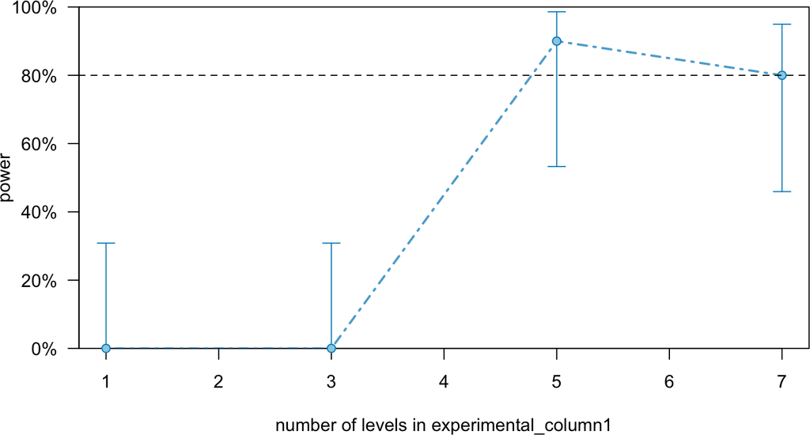

#### 2.2.1.2 Associations with hippocampus volume

Next, we can first ask the question whether or not the proportion of nuclei derived from each of the mice are associated with their hippocampus volumes. Note, more neuro-degeneration is linked to smaller hippocampus volumes. More exactly, we want to test whether or not there is a change in the log odds of cluster membership in cluster 7 corresponding to a unit change in the hippocampus volume. The above data provided includes the hippocampus volume for each mouse.

```r
##Associations of cell-type proportions with hippocampus volume
design@condition_column = "Hippocampus_Vol_mm"
design@condition_is_categorical = FALSE
design@experimental_columns = c("animal_model", "sample_id")

diagnose_res <- diagnoseDataModel(data, design, model)
```

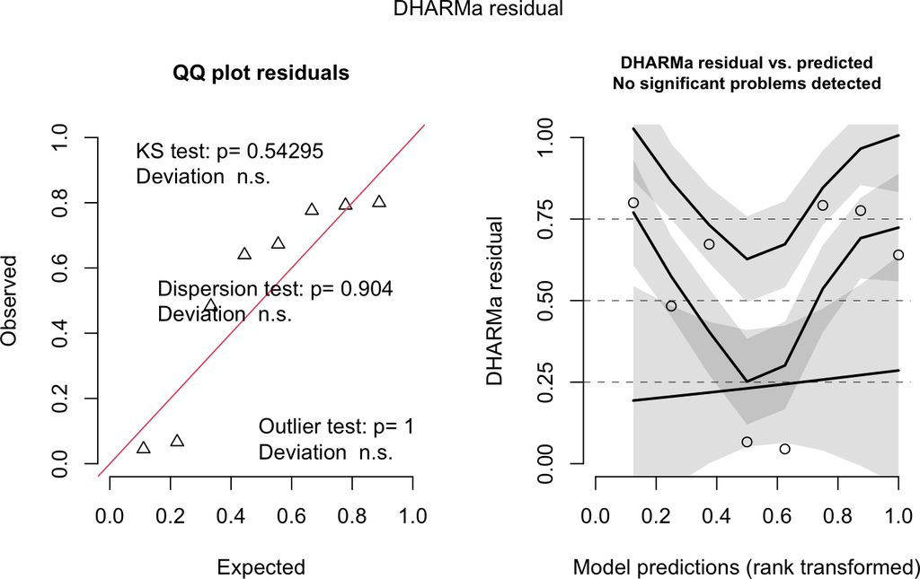

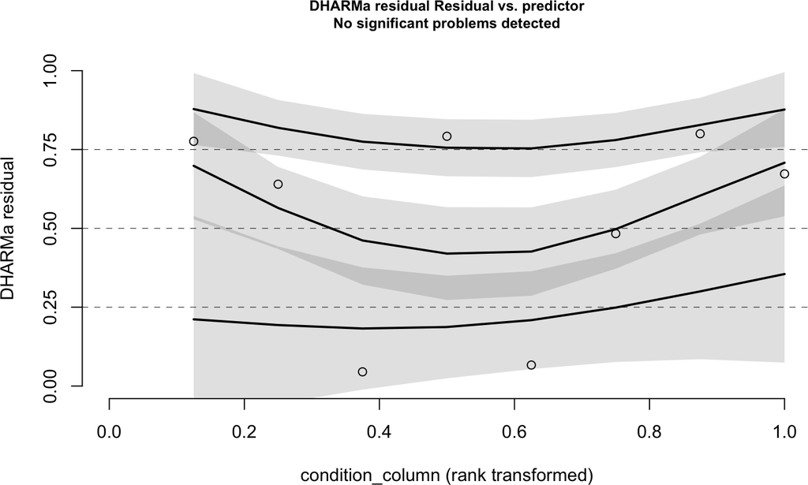

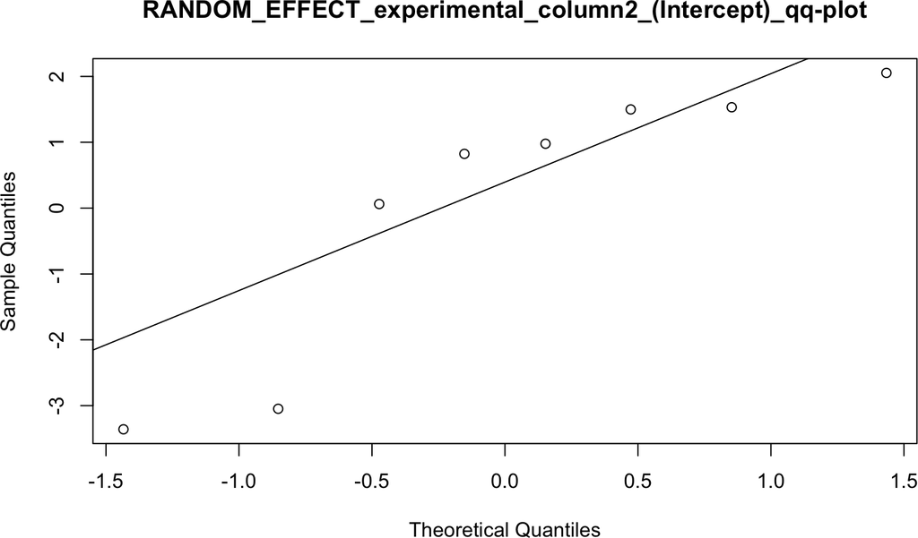

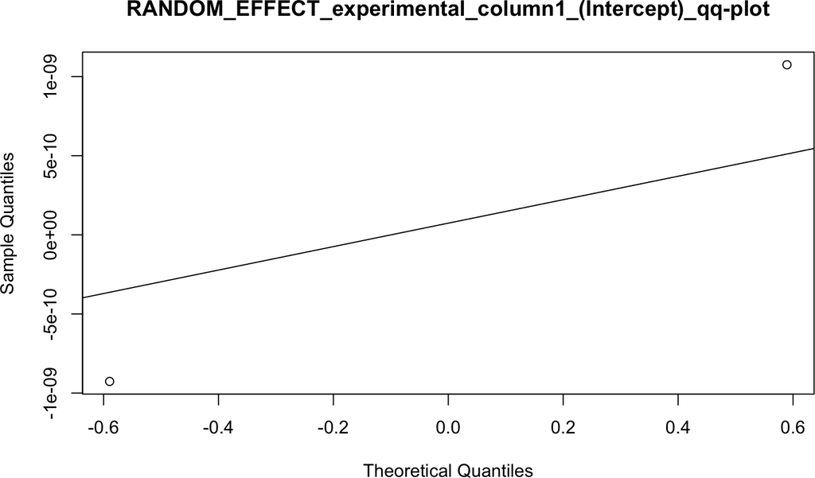

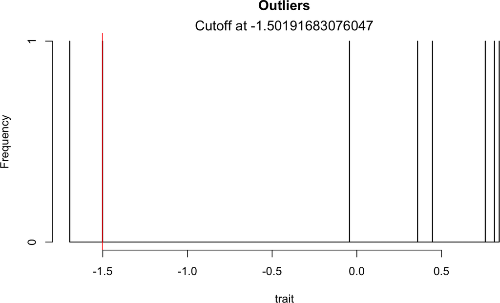

We can also estimate the parameter of interest - log odds ratio of cluster 7 membership per unit increase in hippocampus volume of associated mouse.

```r
estimate_res <- getEstimatesOfInterest(data, design, model)
```

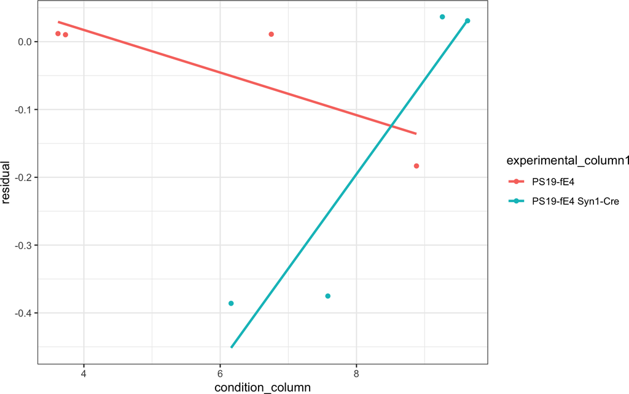

```r
print(estimate_res[[1]])
```

```
## Generalized linear mixed model fit by maximum likelihood (Laplace
##   Approximation) [glmerMod]
##  Family: binomial  ( logit )
## Formula:
## cbind(response_column, (total_column - response_column)) ~ condition_column +
##     covariate + (1 | experimental_column1) + (1 | experimental_column2)
##    Data: fixed_global_variable_data
##
##       AIC       BIC    logLik -2*log(L)  df.resid
##     105.2     105.6     -47.6      95.2         3
##
## Scaled residuals:
##      Min       1Q   Median       3Q      Max
## -0.57752 -0.13043  0.00696  0.02846  0.06210
##
## Random effects:
##  Groups               Name        Variance  Std.Dev.
##  experimental_column2 (Intercept) 4.375e+00 2.092e+00
##  experimental_column1 (Intercept) 1.201e-09 3.465e-05
## Number of obs: 8, groups:  experimental_column2, 8; experimental_column1, 2
##
## Fixed effects:
##                  Estimate Std. Error z value Pr(>|z|)
## (Intercept)       -0.2808     2.5591  -0.110   0.9126
## condition_column  -0.6509     0.3375  -1.929   0.0537 .
## covariateM        -0.6567     1.5052  -0.436   0.6626
## ---
## Signif. codes:  0 '***' 0.001 '**' 0.01 '*' 0.05 '.' 0.1 ' ' 1
##
## Correlation of Fixed Effects:
##             (Intr) cndtn_
## condtn_clmn -0.909
## covariateM  -0.274 -0.021
## optimizer (Nelder_Mead) convergence code: 0 (OK)
## boundary (singular) fit: see help('isSingular')
```

And calculate the statistical power to estimate this association for different numbers of animals per group.

```r
power_res <- calculatePower(data, design, model, power_param)
```

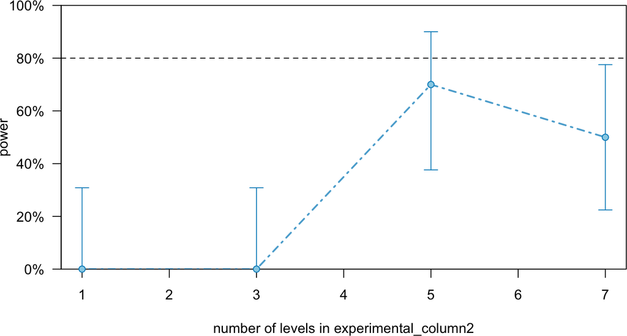

### 2.2.2 Gene expression associations with genotype

We will now estimate the association of the expression levels of the Snhg11 gene with genotype among cells in cluster 7 in the same data set. We will now load the raw counts for this gene and create the relevant RMeDesign, ProbabilityModel and PowerParams objects.

```r
template_dir <- "~/Dropbox (Gladstone)/calcPower f1000_manuscript/Final_paper_materials/Revisions/input_templates/single_cell_data/gene_expression_with_genotype/"

data <- read.csv(paste0(template_dir, "raw_counts_Snhg11_gene_cluster_7_snRNAseq_Koutsodendris_et_al_2023.csv"), header = T)
# data %<>% mutate(genotype = gsub(" ", "-", genotype))
# data %>% write.csv(., paste0(template_dir, "raw_counts_Snhg11_gene_cluster_7_snRNAseq_Koutsodendris_et_al_2023.csv"), row.names = F)
head(data)
```

```
##    y    orig.ident nCount_RNA nFeature_RNA percent.mt sample_number
## 1 20 SeuratProject       2878         1716 0.03474635           S10
## 2  6 SeuratProject       9350         3682 0.05347594           S10
## 3 22 SeuratProject       2949         1735 0.03390980           S10
## 4 12 SeuratProject       4529         2494 0.04415986           S10
## 5 14 SeuratProject       3044         1866 0.03285151           S10
## 6  9 SeuratProject      10636         3957 0.03760812           S10
##   mouse_number genotype sex Cre ApoE      dob age_perfused date_perfused
## 1          154 PS19-fE4   F   - E4/4 10/30/19         10.3        9/7/20
## 2          154 PS19-fE4   F   - E4/4 10/30/19         10.3        9/7/20
## 3          154 PS19-fE4   F   - E4/4 10/30/19         10.3        9/7/20
## 4          154 PS19-fE4   F   - E4/4 10/30/19         10.3        9/7/20
## 5          154 PS19-fE4   F   - E4/4 10/30/19         10.3        9/7/20
## 6          154 PS19-fE4   F   - E4/4 10/30/19         10.3        9/7/20
##   date_of_nuclear_isolation nCount_SCT nFeature_SCT SCT_snn_res.0.7
```

[output cut: 20 more lines]

```r
design <- readDesign(paste0(template_dir,"design_gene_expression.json"))
print(design)
```

```
## An object of class "RMeDesign"
## Slot "response_column":
## [1] "y"
##
## Slot "covariate":
## [1] "sex"
##
## Slot "condition_column":
## [1] "genotype"
##
## Slot "condition_is_categorical":
## [1] TRUE
##
## Slot "experimental_columns":
## [1] "sample_number"
##
## Slot "crossed_columns":
## NULL
##
## Slot "total_column":
## [1] "library_size"
##
## Slot "outlier_alpha":
## [1] 0.05
##
## Slot "na_action":
## [1] "complete"
##
## Slot "include_interaction":
## [1] FALSE
##
## Slot "random_slope_variable":
## NULL
```

```r
model <- readProbabilityModel(paste0(template_dir,"prob_model.json"))
print(model)
```

```
## An object of class "ProbabilityModel"
## Slot "error_is_non_normal":
## [1] TRUE
##
## Slot "family_p":
## [1] "negative_binomial"
```

```r
power_param <- readPowerParams(paste0(template_dir,"power_param.json"))
print(power_param)
```

```
## An object of class "PowerParams"
## Slot "target_columns":
## [1] "sample_number"
##
## Slot "power_curve":
## [1] 1
##
## Slot "nsimn":
## [1] 10
##
## Slot "levels":
## [1] 1
##
## Slot "max_size":
## [1] 1
##
## Slot "alpha":
## [1] 0.05
##
## Slot "breaks":
## NULL
##
## Slot "effect_size":
## NULL
##
## Slot "icc":
## NULL
```

Note, we will assume the underlying probability distribution for the counts is negative binomial and will control for differences in the sequencing depths or the total reads each cell receives using `library_size`.

Diagnosis of the data and the model

```r
diagnose_res <- diagnoseDataModel(data, design, model)
```

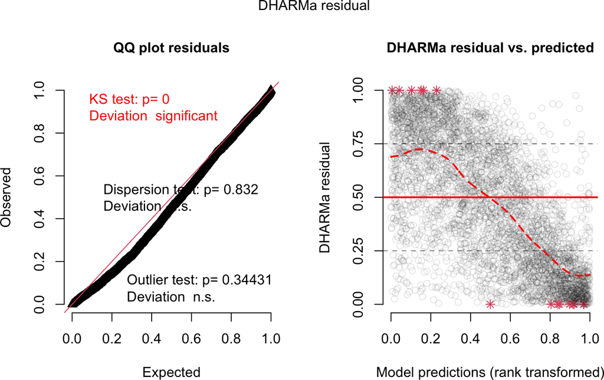

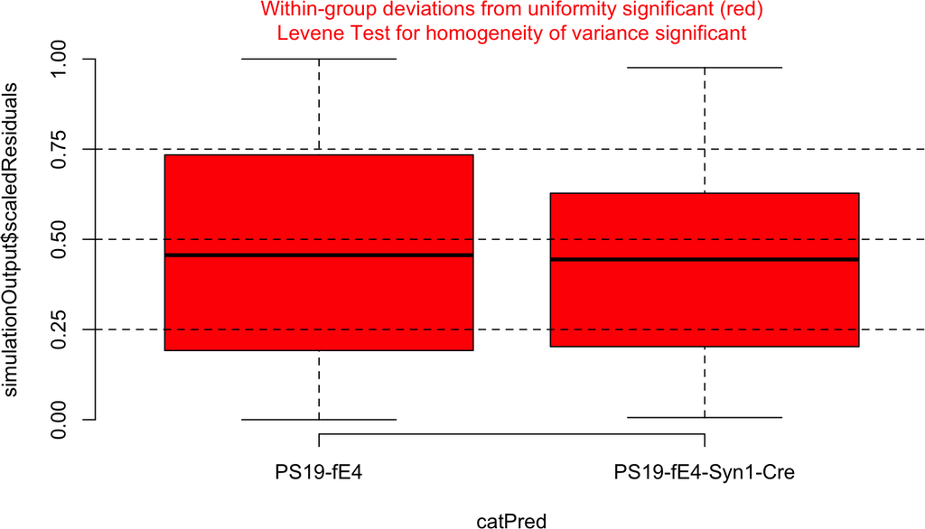

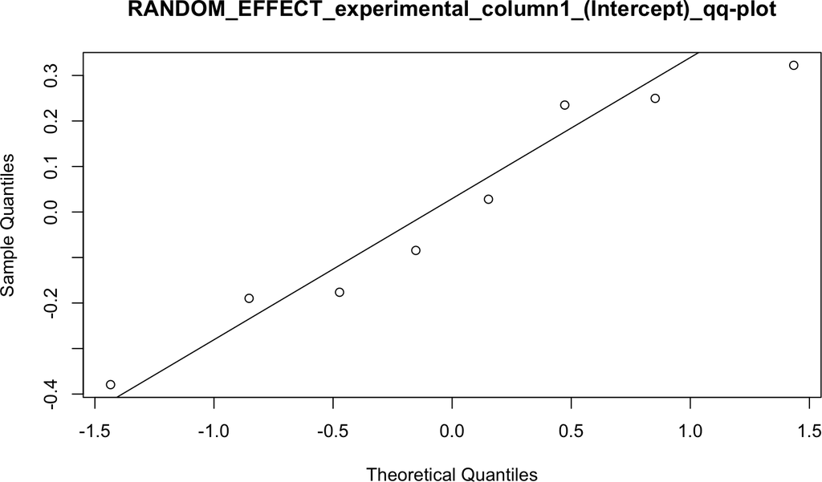

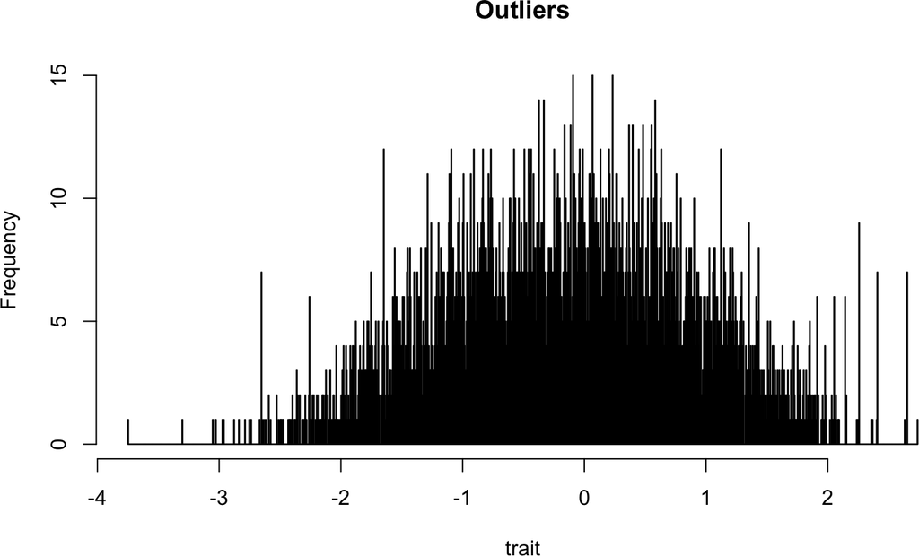

Estimate log-fold change of the Snhg11 gene with genotype.

```r
estimate_res <- getEstimatesOfInterest(data, design, model)
```

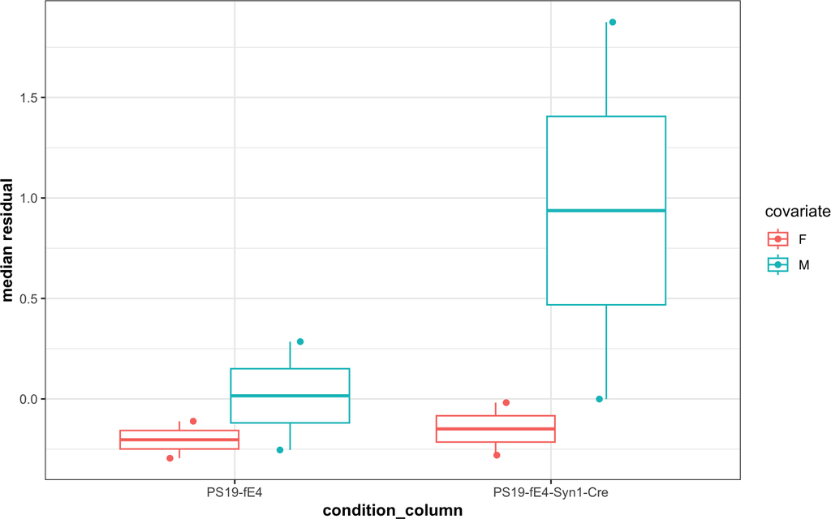

```r
print(estimate_res[[1]])
```

```
## Generalized linear mixed model fit by maximum likelihood (Laplace
##   Approximation) [glmerMod]
##  Family: Negative Binomial(4.914)  ( log )
## Formula:
## response_column ~ condition_column + covariate + (1 | experimental_column1) +
##     offset(log(total_column))
##    Data: fixed_global_variable_data
##
##       AIC       BIC    logLik -2*log(L)  df.resid
##   28790.0   28821.9  -14390.0   28780.0      4297
##
## Scaled residuals:
##     Min      1Q  Median      3Q     Max
## -1.8485 -0.7485 -0.1820  0.5882  5.4549
##
## Random effects:
##  Groups               Name        Variance Std.Dev.
##  experimental_column1 (Intercept) 0.07378  0.2716
## Number of obs: 4302, groups:  experimental_column1, 8
##
## Fixed effects:
##                                   Estimate Std. Error z value Pr(>|z|)
## (Intercept)                        -5.1736     0.1756 -29.460   <2e-16 ***
## condition_columnPS19-fE4-Syn1-Cre   0.4622     0.2280   2.027   0.0426 *
## covariateM                          0.1356     0.2335   0.581   0.5616
## ---
## Signif. codes:  0 '***' 0.001 '**' 0.01 '*' 0.05 '.' 0.1 ' ' 1
##
## Correlation of Fixed Effects:
##             (Intr) c_PS19
## c_PS19-E4-S -0.450
## covariateM  -0.588 -0.076
```

```r
power_param@effect_size <- log(2)
power_res <- calculatePower(data, design, model, power_param)
```

[output not shown]